# Measures Taken Formal Analysis Chapter Write-Up

Noah Zeldin

6/2/2021

**Introductory Remarks**

The following text is a short excerpt from section 3 of chapter 2 of my dissertation. The code for the computations and visualizations can be found [here](https://github.com/noahzeldin/dissertation/blob/main/mt_music_analysis.md). As with the rest of the dissertation, I provide abbreviated references for other sources, as full references are available in the bibliography.

[…]

Examining the choral texture in *The Measures Taken* will further reveal the extent to which Eisler prized textual comprehensibility, while engaging with the aforementioned debate surrounding the role of monophony and polyphony in workers’ choral music. As Manfred Grabs and Taekwan Kim have both correctly noted in their analyses, the choral writing is “overwhelmingly homophonic.”[^1] However, this implicitly statistical assertion can of course be concretized and verified.[^2]

As a proportion of the total number of measures (weighted by duration), in which the choir is active, homophony unquestionably dominates, constituting approximately 57%. This is followed by monophony with 22% and then polyphony with 18%. The single antiphonic passage at the beginning of “Lob der Partei” (discussed at length below), constitutes the remaining 3%.[^3]

Let us now examine choral texture at a more local level. Below is a chart showing the textural proportions of each piece.

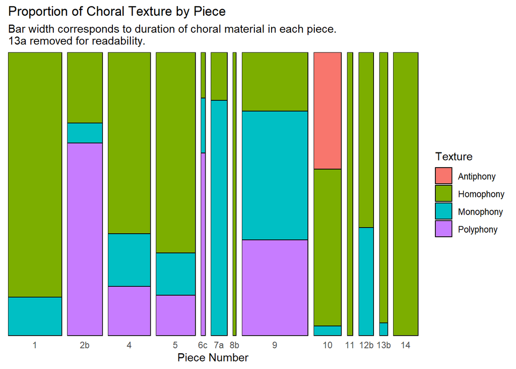

The above analysis of the choral textures of *The Measures Taken* affirm my claim that the work may be viewed as a step towards the “agitpropization” of worker’s choral music, that is, as a balancing of simple monophony and complex polyphony. As expected, homophony and monophony are clearly the dominant textures, while polyphony is used much more sparingly. Homophony, however, is a broad category. If texture is viewed as a spectrum, ranging from the least complex (monophony) to the most complex (polyphony), there are, of course, gradients between each kind of texture. Thus, certain, reduced variants of homophony will begin to resemble monophony, while others that are more complex will approach polyphony. As I will demonstrate, a closer examination of the choir’s homophonic passages is necessary to assess the extent of “agitpropization” in *The Measures Taken*.

As preparation, let us first consider a particularly conspicuous tendency in Eisler’s choral writing, namely, the tendency to reduce simultaneous lines by grouping different voices together, generally in pairs.[^4] One can discern two clear objectives from this reduction via grouping: 1) lessening the difficulty of a given passage and 2) increasing the comprehensibility of the text. Let us, then, focus for a moment on this reduction via grouping, as it plays a significant role in Eisler’s “agitpropization” of workers’ choral music.

After computing the proportions of groupings in the choir’s sung material, as gauged by number of measures (weighted by duration), we find that the most common grouping by a large margin is a) sopranos paired with tenors and b) altos paired with basses (37%).[^5] It is also far and away the most common grouping for homophonic passages (46%). This two-paired grouping is followed by tenors paired with basses (16%) and then by no groupings (11%), which of course includes passages featuring only one or two voices. The final grouping of significance is that of all four voices in tutti monophony (10%), in all cases, full-fledged unison.[^6]

These figures demonstrate the full extent of Eisler’s reduction of simultaneous lines in the choir’s written material. As stated above, I argue that this reduction via grouping has the twin goals of lessening difficulty and increasing textual comprehensibility, both of which “agitpropize” the choral writing. Additionally, this reduction via grouping also can be interpreted as a technique by which to render homophony more monophonic (the choice texture of agitprop songs and *Kampflieder*).

As a quick aside, I have noted above and in the previous chapter that most of the mixed choirs of the DASB were located in metropolises and major industrial centers, while men’s choirs were far more numerous and more widespread. How does Eisler engage with these dynamics in *The Measures Taken*? Comparing the durations of the male and female voices, we find that the male voices constitute 59% of the choir’s sung material, while female voices constitute 41%. Unsurprisingly, this discrepancy arises largely from the inclusion of two pieces that use men’s choir without sopranos or altos, no. 5. “Gesang der Reiskahnschlepper” and no. 7a. “Streiklied” (53% of the discrepancy in fact).

It is immediately clear to any listener that Eisler’s choral writing for *The Measures Taken* is resolutely modernist, even though it undoubtedly engages with the choral-musical traditions that would have been familiar to the worker-singers performing the work.[^7] Several elements can be identified as the chief contributors to the work’s musical modernism. The first, already discussed above, is the instrumentation, namely, Eisler’s decision to exclude strings and woodwinds in favor of brass instruments and percussion. Then, there is the relatively chromatic, though by no means atonal harmony and the tight, pounding rhythms with frequent meter changes. I will now briefly discuss these latter two elements: pitch and rhythm. Although they both constitute key aspects of the music and increase the level of difficulty for the singers (thereby dampening somewhat the decreased difficulty achieved through the aforementioned reduction via grouping), these two elements lie beyond the primary focus of the analysis, which, as indicated above, is the texture of the choral writing.

Let us begin with pitch. While no piece exhibits fully chromatic choral writing (that is, none features all twelve pitches), several approach this: Three feature eleven pitches, one features ten, another features nine, while four feature eight. The three pieces that feature eleven pitches (2b. “Lob der U.S.S.R.”, 9. “Ändere die Welt” and 12b. “Wir sind der Abschaum der Welt”) contain politically neutral texts,[^8] which I think is no coincidence, as an expanded tonal vocabulary arguably makes the text less comprehensible. (I discuss the relationship between musical complexity and textual content at length below.) The chromaticism of several important pieces arguably demonstrates that although Eisler clearly reduced textural complexity, he decided against a comparably universal reduction for pitch and tonality. Perhaps this was a way for him to balance the demands of composing a politically charged work for non-professional musicians, while retaining modernist elements.

Let us now move on to rhythm and meter. As previous scholars have noted, tight, pounding rhythms are an important feature of *The Measures Taken*. The noticeable lack of syncopated rhythms, complex tuplets and the like in the choral material arguably constitutes a counterweight to the remarkably frequent meter changes,[^9] which significantly increase the difficulty of the music and are another indication of the necessity of a professional conductor.[^10] Let us first consider the five pieces with the highest number of meter changes.

| Piece No. | Meter Changes | Avg. Rate of Meter Change (sec) | Duration of Piece (sec) |
| --- | --- | --- | --- |
| 4 | 18 | 13.73 | 247.22 |
| 3b | 12 | 2.47 | 29.61 |
| 1 | 9 | 32.76 | 294.86 |
| 2b | 9 | 13.82 | 124.35 |
| 9 | 8 | 36.14 | 289.09 |

Eighteen meter changes in the course of a single piece for a non-professional choir (no. 4 “Lob der illegalen Arbeit”) is rather extraordinary. Next, we can consider the five pieces with the fastest rate of meter change.

| Piece No. | Meter Changes | Avg. Rate of Meter Change (sec) | Duration of Piece (sec) |
| --- | --- | --- | --- |
| 6b | 4 | 1.90 | 7.62 |
| 3b | 12 | 2.47 | 29.61 |
| 12a | 5 | 5.64 | 28.18 |
| 4 | 18 | 13.73 | 247.22 |
| 2b | 9 | 13.82 | 124.35 |

Examining the average rate of meter change is arguably even more impressive than examining the counts. In 6b. “Lenin-Zitat” [“Lenin-Quote”], rhythmically notated speech for mixed choir acapella, the meter changes on average less than every two seconds. The closely related 3b. “Sprechchor” (“Wer für den Kommunismus kämpft”) [“Whoever fights for Communism”], also scored for rhythmically notated speech but now accompanied by snare drum, averages just under two and a half seconds per meter change. (These two pieces are discussed in greater detail below.) However, given that the choir does not have to worry about finding pitches in 3b and 6b, it perhaps comes as little surprise that these are the two pieces with the fastest rates of meter change.

Why is all of this surprising? Let us consider the following. Eisler composed *The Measures Taken* for the non-professional choirs of the DASB. As a result, one would expect some reduction in musical complexity in the interest of lessening the difficulty of performing the music. As I have shown above, Eisler indeed pursued this route, especially with regard to texture. However, I would wager the speculative claim that those worker-singers, who could read musical notation, would have been more familiar with quarter- or even eighth-note-based meters than with half-note-based meters.[^12] Thus, the frequency with which Eisler used the latter could be considered surprising. Then, there is the question of duple/quadruple and triple meters. Considering the militantly political nature of the work, I think it is surprising that only a very slight majority of the music is in a duple or quadruple meter, as these are the meters used for marches and thus generally for political anthems. Moreover, the compound duple meter 6/4 constitutes roughly 4.8% of the total or 9.2% of the aggregated duration of the duple/quadruple meters. If one disregards the 6/4 measures, to which it is very difficult to imagine marching, the two meter groupings then have virtually equal aggregate durations. Eisler’s use of triple meters could perhaps be interpreted as a subtle subversion of the march and anthem, as can his insertion of the intentionally awkward 1/4 bar of no. 7a. “Streiklied” [“Strike Song”] (m. 9), the most monophonic and “agitpropized” piece in the whole work.[^13]

From these observations, it can be concluded that Eisler takes a very specific approach to the choral writing of *The Measures Taken*. In particular, his approach to texture constitutes one of the defining compositional qualities of the work and is especially relevant to the present study. Expanding on this macro-level analysis of choral texture, I will now shift to a close examination of several particularly significant passages that demonstrate Eisler’s priorities regarding textual comprehensibility.

[…]

[^1]: Both use the phrase “überweigend homophon.” Kim, *Das Lehrstück*, 186; Grabs, “Die Musik,” 214. Textural reduction is also mentioned in Rienäcker, “Musik als Agens,” 187-88.
[^2]: See McKay, “Statistical Reasoning in Music Analysis,” n.p. As McKay aptly notes at the beginning of his essay, claims about e.g. “the relative frequency of chord progressions and other musical features” are – to paraphrase very slightly – “implicitly mathematical,” just as “[a]ny theory of music that makes any claims about a repertoire depends on statistical arguments.”
[^3]: I do not consider mm. 22-27 of “Lob der illegalen Arbeit” to be antiphonic. Since the basses sing throughout, I do not consider it a true ‘call and response’ passage. Note also that the unweighted proportions, i.e. measured by number of measures without regard to duration, change meaningfully only for homophony and polyphony, which change respectively to 64% and 12%.
[^4]: I am grateful to Eisler scholar, Dr. Johannes Gall, for discussing this point with me and affirming its significance.
[^5]: This grouping is also noted in Grabs, “Die Musik,” 214.
[^6]: The most significant passage of four-voice unison occurs at the beginning of “Ändere die Welt” (mm. 2-18). Also, note that the ranking of these top proportions remain unchanged if instead of considering groupings of groupings, e.g. sopranos paired with tenors grouped with altos paired with basses, groupings are considered individually. However, the pairing of sopranos with tenors does appear slightly more often and that of altos with basses.
[^7]: See, for instance, Dümling, *Lasst euch*, 291-94 and 298.
[^8]: I consider the text of “Wir sind der Abschaum der Welt’ to be politically neutral, because there is no mention of Communism, the Communist Party, the Soviet Union, etc. Instead, the song discusses general issues like fighting”exploitation" [*Ausbeutung*] and and helping “the oppressed” [*die Unterdrückten*], neither of which belongs to Communists and could just as easily have been supported by the rival Social Democrats and possibly even progressive liberals. NB: The first stanza in the score corresponds to neither the first or second version of the text in the BFA. Cf. Eisler, *Die Maßnahme*, 113-17 and GBA 3:95-96 and 122-23.
[^9]: This general tendency is also noted in Kim, *Das Lehrstück*, 196.
[^10]: However, it is arguably the “Gesang der Reiskahnschlepper” [“Song of the Rice Barge Haulers”], which demands most from the conductor, who has to navigate 9 tempo changes and frequent shifts between male choir, solo tenor and orchestra. NB: This count and rate of tempo change (every 26.14 seconds) is rivaled only by “Song von der Ware,” which, as stated above, is a work for solo tenor and orchestra with a negiligible few measures of easy choral material at the very end (7 tempo changes at an average of every 26.73 seconds).
[^11]: These appear in the following pieces: no. 1, mm. 12 and 15; no. 6b, mm. 4 and 9; and no. 7a, m. 9. I discuss the final of these below.
[^12]: One could of course conceivably conduct a statistical survey of the surviving literature of the DASB choirs, but this demanding undertaking clearly lies beyond the scope of the present study.
[^13]: This could be compared with Eisler’s intentionally awkward insertions of 2/4 bars in the “Solidaritätslied” [“Solidarity Song”], the main meter of which is 4/4. See the analysis in Dümling, *Lasst euch*, 328-30 (and more generally 320-31). See also the convincing harmonic analysis of the song in Kutschke, “New ‘Old Leftist’ Aesthetics,” 252-56, where the author writes of “a specific disparity of melody and accompanying chords” (252). Another complementary musical analysis is offered in Bullivant, *Alan Bush*, 70-72, while Dümling offers an analysis of the meter of Brecht’s text in BHB 2:198.